# IMPORTANCIA DEL MONITOREO DE LA TEMPERATURA SUPERFICIAL DEL MAR EN EL PACIFICO ECUATORIAL

Claudia Morales

## Introducción

El Perú es uno de los pocos países en el mundo que requiere dos índices para el monitoreo de El Niño debido a que tiene tanto impactos locales (lluvias en la costa, perturbaciones al ecosistema marino, etc.), como remotos a través de teleconexiones atmosféricas (tendencia a menores precipitaciones en los Andes y Amazonía)[1].

En la actualidad, la comunidad científica considera al fenómeno El Niño como parte de un mecanismo de interacción océano-atmósfera en el Pacífico Ecuatorial (PE) que tiene repercusiones climáticas a nivel mundial. Un concepto físico aceptado por los científicos establece que el PE conserva un equilibrio entre las aguas frías del Este y las aguas calientes del Oeste. Esta diferencia mantiene un viento con dirección Oeste que provoca el efecto afloramiento ecuatorial en el extremo Este, como consecuencia se tiene bajas temperaturas en dicha región. El equilibrio se rompe cuando, por algún motivo, los vientos hacia el Oeste se debilitan ocasionando la aparición de ondas ecuatoriales, conocidas como ondas de Kelvin. Estas ondas atraviesen el PE hundiendo las isotermas a lo largo de su trayectoria, por lo que provoca un calentamiento en el Centro y extremo Oriental del Pacífico [2].

El formato NetCDF (Network Common Data Format) fue creado por UNIDATA como formato estándar para que sea usado en algunos de sus softwares que ofrece a la comunidad científica. La característica de este formato que contiene la suficiente información para poder saber qué clase de data se encuentra en el archivo (tipo de variable, unidades, dimensiones, institución que la creo, etc)[3].

## Materiales y métodos

La metadata del archivo netCFD utilizado en este trabajo tiene las siguientes variables: longitud, latitud, tiempo, temperatura superficial del mar, salinidad, pH, producción vegetal integral de fitoplancton pequeño y grande.

Utilizando el programa R, elaboramos cuatro figuras con las variables antes mencionadas en años Niño y en otros que no fueron considerados como tal. Las anomalías se calcularon usando la climatología mensual para el período base 1959-2004.

El diagrama de Hovmoller lo empleamos para representarla temperatura superficial del mar y observar su variación a través del tiempo (abcisas) y la latitud (ordenadas). Las otras tres figuras, son mapas que representan la producción vegetal integral y la salinidad superficial del mar que nos permitieron relacionar otras caracteristicas tanto biológica como física ligadas al cambio de la temperatura de la superficie del mar.

## Resultados y discusión

En la figura 1, comparamos la temperatura de la superficie del mar durante el período base 1959-2004 con el primer año de mi vida (a) y los dos eventos denominados extraordinarios de 1982-1983 (b) y de 1997-1998 (c), los cuales tuvieron una duración de 17 y 19 meses respectivamente[4].

Al evaluar las condiciones físicas de la superficie del mar observamos en los dos últimos rectangulos negros, que corresponden a los eventos Niño ya mencionados, una notable intensidad térmica (23C aprox.) que avanza mas allá de los 10 LS. Por el contrario, en el año 1978 se aprecia que las aguas oscilaban los 20C e incluso el Comité Técnico del Estudio NAcional del Fenómeno del Niño (ENFEN) lo catalogaron como Niña débil.

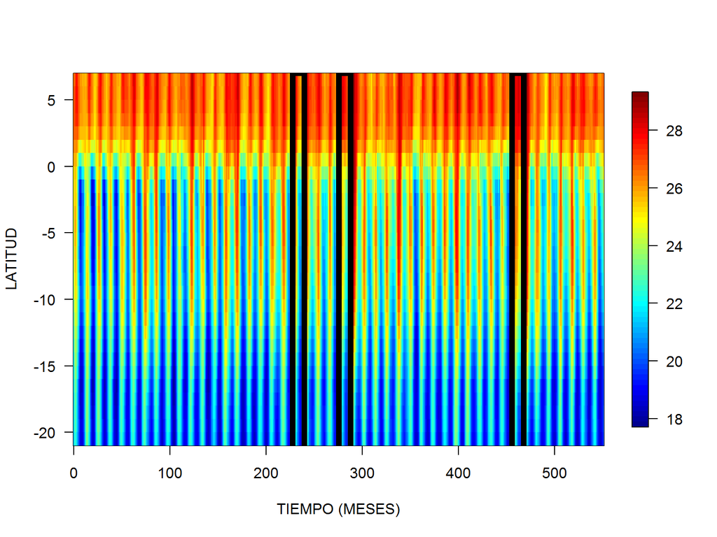

La temperatura de la superficie del mar (TSM) es una de las principales variables climáticas y es esencial para el pronóstico a escala interanual, ya que determina en gran parte el estado instantáneo de la atmósfera, por ejemplo modulando la probabilidad de lluvias intensas en la costa de Perú, pero también porque es resultado de la dinámica oceánica lenta que es la que permite las predicciones con meses de anticipación (la atmósfera por sí sola no tiene “memoria”)[5].

Otra parámetro no evaluado en este trabajo es la presencia de las ondas Kelvin a través de la profundizacion de la isoterma de 20°C, aproximadamente en el centro de la termoclina;la intensidad o debilitamiento de las ondas Kelvin coincide con las anomalías de la TSM.

La salinidad superficial del mar en los períodos evaluados se mantuvieron similar al promedio base; esto es más notorio a lo largo de la costa peruana y en el Ecuador es donde se aprecia un ligero cambio. En eventos Niño, la distribución vertical tanto de la temperatura y de la salinidad es afectada, tal como sucedió en 1997 donde la salinidad aumentó casi linealmente desde 34 usp en la superficie, hasta 34.7 usp en el nivel de 150m [6].

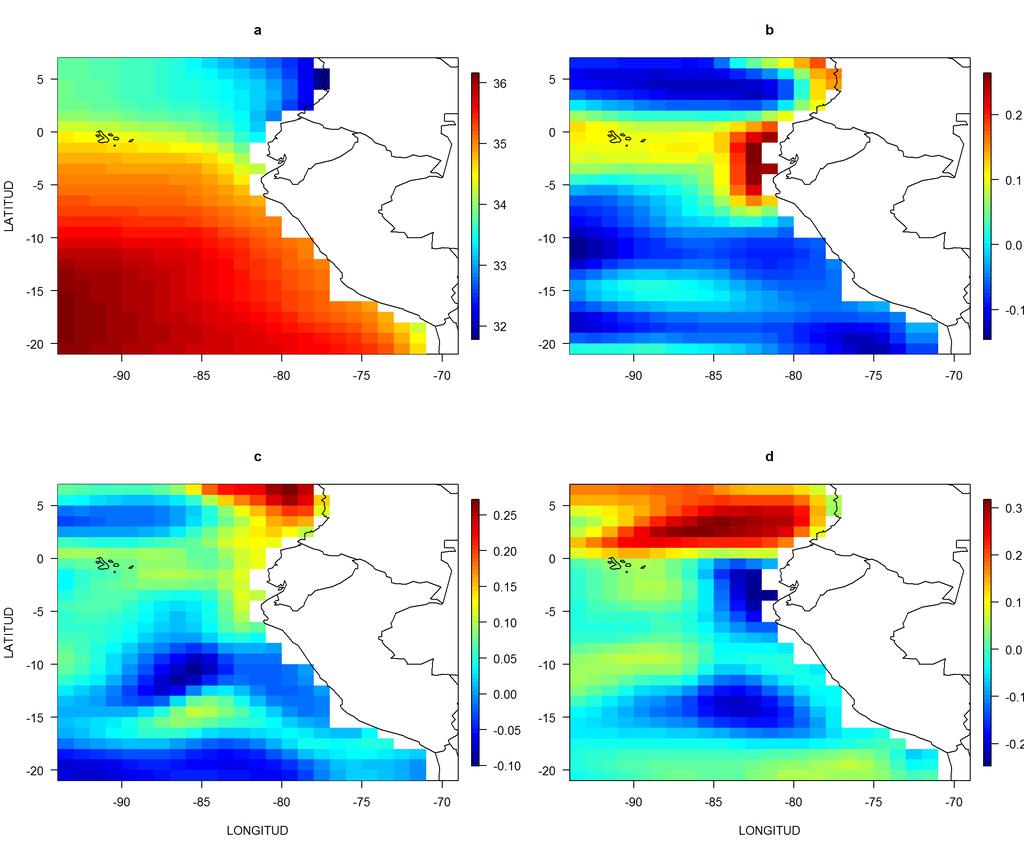

**Figura 2: Salinidad superficial del mar a)promedio del período 1959-2004, anomalía de b)mi primer año de vida (1978-1979), c)período 1982-1983 y b) período 1997-1998**

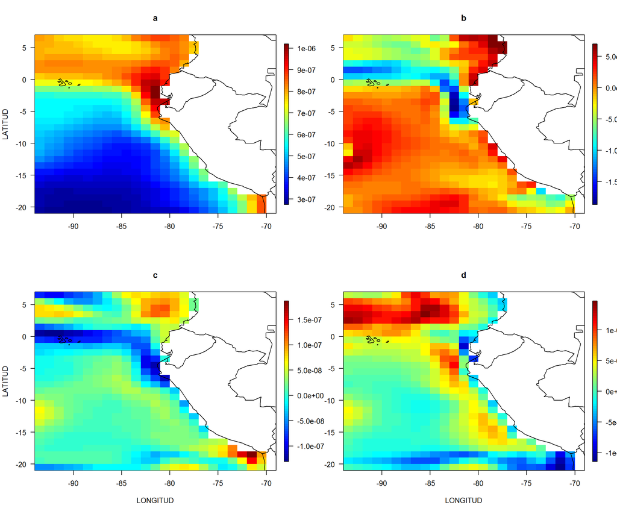

**Figura 3: Produccion vegetal integral (fitoplancton pequeño) en el a)promedio período 1959-2004, anomalía de b)mi primer año de vida (1978-1979), c)período 1982-1983 y b) período 1997-1998**

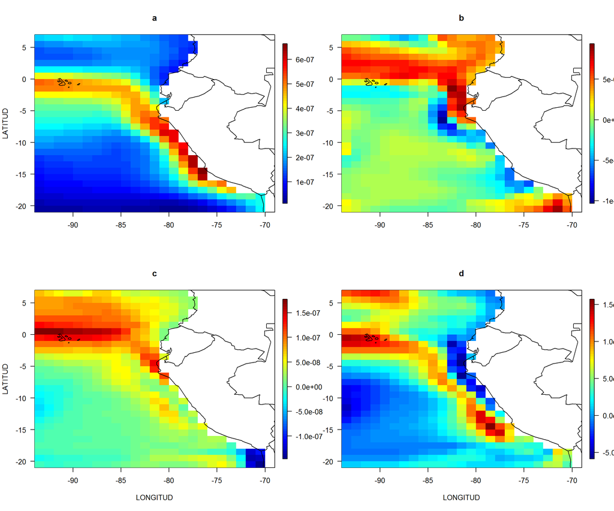

**Figura 4: Producción vegetal integral (fitoplancton grande) en el a)promedio período 1959-2004, anomalía de b)mi primer año de vida (1978-1979), c)período 1982-1983 y b) período 1997-1998**

## Conclusiones

La temperatura superficial del mar en mi primer año de vida (1978), indicó que no se trataba de un año Niño sino todo o contrario. La TSM, ha demostrado ser un parametro que influye en aspectos biologicos en el oceóno.

A nivel superficial, la salinidad es similar a lo largo de la costa peruana en ambas etapas tanto de El Niño como de La Nina (1978).La salinidad superficial no es afectada drásticamente por el aumento de la temperatura de la superficie del mar.

La productividad primaria en 1978 no se ve afectadad ya que sus valores son similares al del promedio.

El monitoreo constante de distintos parámetros físicos, químicos y biológicos ayuda a comprender como los diversos fenomenos influyen positva o negativamente en un ecosistema.

## Referencias

1. Takahashi, K., K. Mosquera y J. Reupo. (2014). El Índice Costero El Niño (ICEN): historia y actualización. Boletín Técnico “Generación de modelos climáticos para el pronóstico de la ocurrencia del Fenómeno El Niño”, Instituto Geofísico del Perú, Febrero, 1(2):8-9.
2. Investigación para la Prevención de Desastres en Variabilidad y Cambio Climático. El Niño en el Perú. Recuperado de: http://www.met.igp.gob.pe/variabclim/nino_peru.html
3. Mosquera, K. A.(08 de Mayo del 2006).El formato NetCDF.Recuperado de:http://www.met.igp.gob.pe/users/kobi/NETCDF/ 4.Comité Técnico del Estudio Nacional del Fenómeno El Niño (ENFEN).(Lima, 9 de abril del 2012). Definición operacional de los eventos El Niño y la Niña y sus magnitudes en la costa del Perú. Recuperado de: http://www.imarpe.pe/imarpe/archivos/informes/imarpe_comenf_not_tecni_enfen_09abr12.pdf
4. Takahashi, K.(2017). Estimación de la distribución de la temperatura superficial del mar. Boletín Técnico “Generación de modelos climáticos para el pronóstico de la ocurrencia del Fenómeno El Niño”. Instituto Geofísico del Perú, Febrero 4(2):8-10. 6.Trasviña, A. Lluch, D., Filonov, A., y A. Gallegos. Oceanografia y el Niño. Disponible en:http://www.atmosfera.unam.mx/editorial/libros/el_nino/cap3.pdf
5. Pérez-Arvizu, Esteban M, Aragón-Noriega, E. Alberto, & Espinosa-Carreón, T. Leticia. (2013). Variabilidad estacional de la clorofila a y su respuesta a condiciones El Niño y La Niña en el Norte del Golfo de California. Revista de biología marina y oceanografía, 48(1), 131-141. https://dx.doi.org/10.4067/S0718-19572013000100011